# Lab #3

Nikole Slinger

```r
library(dplyr)
```

```r
library(ggplot2)
gss <- readxl::read_xls('GSS.xls')
# renaming columns with better names
gss <- rename(gss, Year = `Gss year for this respondent`,
       Id = `Respondent id number`,
       HoursWorked = `Number of hours worked last week`,
       MaritalStatus = `Marital status`,
       EducationYears = `Highest year of school completed`,
       Party = `Political party affiliation`,
       Belief = `Belief in life after death`,
       Happiness = `General happiness`,
       Ballot = `Ballot used for interview`)
```

### Problem 1.

Find the average years of education for the respondents with each marital status. Arrange your output in a meaningful order and print. Describe any patterns you find.

```r
# grouping data by marital status and finding average education level
gss %>% group_by(MaritalStatus) %>%
  filter(MaritalStatus != 'No answer') %>%
  summarize(mean_education = mean(as.numeric(EducationYears), na.rm=TRUE)) %>%
  arrange(desc(mean_education))
```

```
## # A tibble: 5 x 2
##   MaritalStatus mean_education
##   <chr>                  <dbl>
## 1 Never married           13.4
## 2 Divorced                13.1
## 3 Married                 13.0
## 4 Separated               11.9
## 5 Widowed                 11.2
```

When looking at the average number of years of education from each possible marital status, we can see that those with the highest average education are the people who have never been married at 13.4 years. The divorced group and the married group have very similar education on average, 13.1 and 13.0 years respectively. People who are seperated have an average education of 11.9 year, and finally the group with the least amount of education on average are those who are widowed at 11.2 years.

### Problem 2.

Create a single data frame containing records for the better educated respondents with each marital status. A “better educated” respondent is someone who has strictly more years of education than the average among those with the same marital status. Print the structure of the data frame.

```r
# creating data frame with
betterEducated <- gss %>% filter((MaritalStatus == 'Divorced' & EducationYears > 13.1) |
                             (MaritalStatus == 'Married' & EducationYears > 13.0) |
                             (MaritalStatus == 'Never married' & EducationYears > 13.4) |
                             (MaritalStatus == 'No answer' & EducationYears > 15.5) |
                             (MaritalStatus == 'Separated' & EducationYears > 11.9) |
                             (MaritalStatus == 'Widowed' & EducationYears > 11.2))
str(betterEducated)
```

```
## tibble [35,967 × 9] (S3: tbl_df/tbl/data.frame)
##  $ Year          : num [1:35967] 1972 1972 1972 1972 1972 ...
##  $ Id            : num [1:35967] 1 4 6 8 12 13 14 15 16 17 ...
##  $ HoursWorked   : chr [1:35967] "Not applicable" "Not applicable" "Not applicable" "Not applicable" ...
##  $ MaritalStatus : chr [1:35967] "Never married" "Married" "Never married" "Never married" ...
##  $ EducationYears: chr [1:35967] "16" "17" "14" "16" ...
##  $ Party         : chr [1:35967] "Ind,near dem" "Not str democrat" "Ind,near dem" "Ind,near dem" ...
##  $ Belief        : chr [1:35967] "Not applicable" "Not applicable" "Not applicable" "Not applicable" ...
##  $ Happiness     : chr [1:35967] "Not too happy" "Not too happy" "Pretty happy" "Not too happy" ...
##  $ Ballot        : chr [1:35967] "Not applicable" "Not applicable" "Not applicable" "Not applicable" ...
```

### Problem 3.

How is the happiness of a respondent related to his/her marriage status? Define that a person is happy if the response to question is “Very happy” or “Pretty happy”.

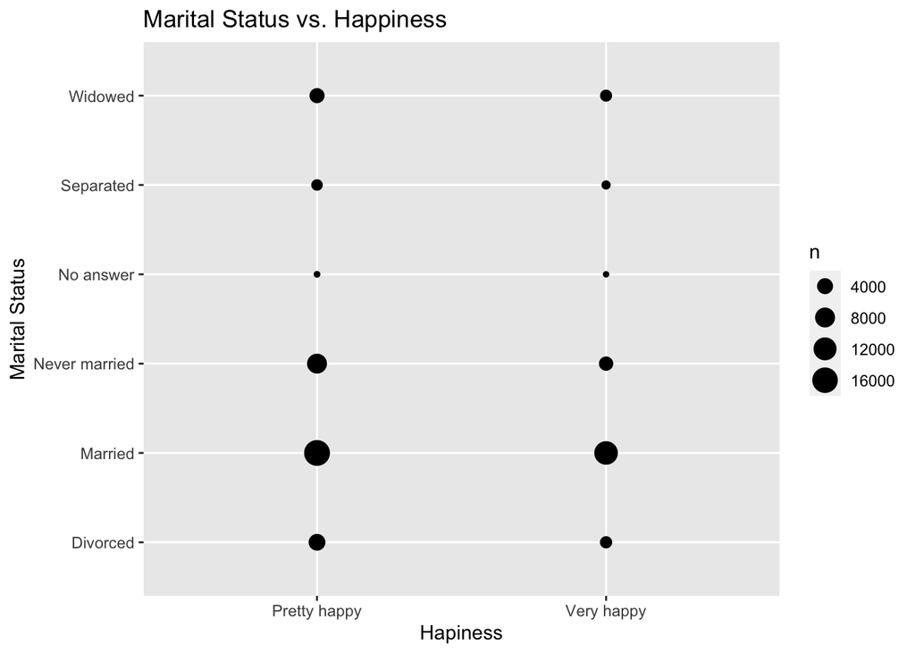

```r
# creating date frame of desired happiness level
happiness <- filter(gss, Happiness == 'Very happy' | Happiness == 'Pretty happy')

p <- ggplot(happiness, aes(x = Happiness, y = MaritalStatus)) + geom_count()
p + ggtitle('Marital Status vs. Happiness') + xlab('Hapiness') + ylab('Marital Status')
```

```r
# getting numerical count
happiness %>% count(MaritalStatus)
```

```
## # A tibble: 6 x 2
##   MaritalStatus     n
## * <chr>         <int>
## 1 Divorced       6180
## 2 Married       29342
## 3 Never married 10686
## 4 No answer        16
## 5 Separated      1487
## 6 Widowed        4675
```

The group with the highest happiness level is the Married group, with 29,342 people that are either ‘Very happy’ or ‘Pretty happy’. The group with the lowest happiness level is people that have been seperated, with only 1,487 total people in the group. We are disregarding the ‘No answer’ group.

### Problem 4.

Does party affiliation affect the relationship you found in the last question?

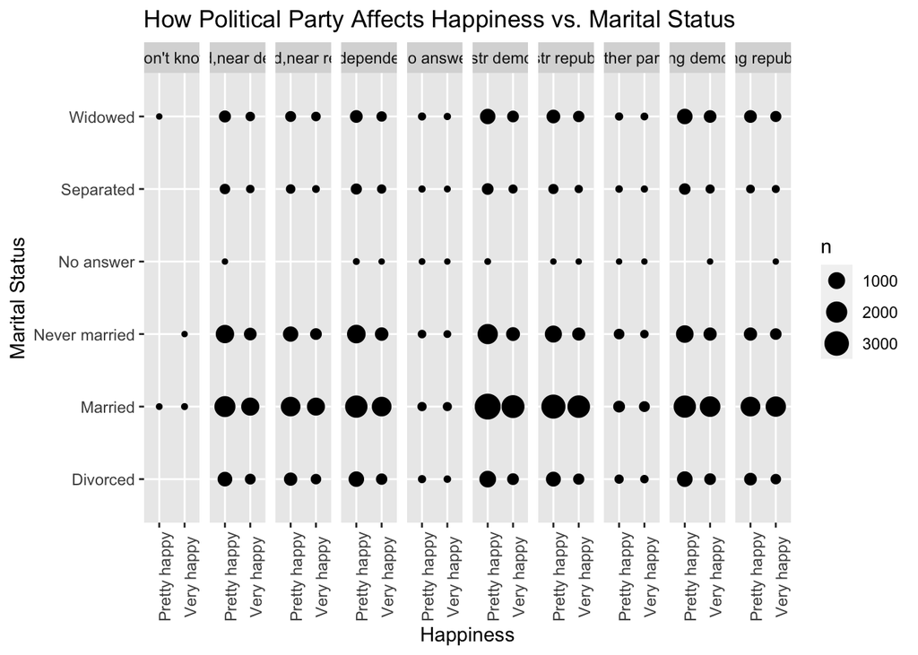

```r
party <- gss %>% group_by(Party) %>%
  filter(Happiness == "Very happy" | Happiness == "Pretty happy")
p <- ggplot(party, aes(x = Happiness, y = MaritalStatus)) + geom_count() +
  facet_grid(cols = vars(Party)) + theme(axis.text.x = element_text(angle = 90))
p + ggtitle('How Political Party Affects Happiness vs. Marital Status') +
  xlab('Happiness') + ylab('Marital Status')
```

```r
# getting numerical count
party %>% count(MaritalStatus)
```

```
## # A tibble: 56 x 3
## # Groups:   Party [10]
##    Party        MaritalStatus     n
##    <chr>        <chr>         <int>
##  1 Don't know   Married           6
##  2 Don't know   Never married     1
##  3 Don't know   Widowed           1
##  4 Ind,near dem Divorced        803
##  5 Ind,near dem Married        3203
##  6 Ind,near dem Never married  1670
##  7 Ind,near dem No answer         1
##  8 Ind,near dem Separated       193
##  9 Ind,near dem Widowed         378
## 10 Ind,near rep Divorced        589
## # … with 46 more rows
```

Politcal party seems to have little, if any, effect on the relationship between Happiness and Marital Status. The Married group is still the most common among the happiest people, with the Never Married group second. The Seperated group is still the smallest, with the least amount of happiest people.

### Problem 5.

How is marital status related to the education of a respondent? What are possible reasons accounting for the patterns you see?

```r
gss %>% group_by(MaritalStatus) %>%
  summarize(mean_education = mean(as.numeric(EducationYears), na.rm=TRUE)) %>%
  arrange(desc(mean_education))
```

```
## # A tibble: 7 x 2
##   MaritalStatus mean_education
##   <chr>                  <dbl>
## 1 No answer               15.5
## 2 Never married           13.4
## 3 Divorced                13.1
## 4 Married                 13.0
## 5 Separated               11.9
## 6 Widowed                 11.2
## 7 <NA>                   NaN
```

### Problem 6.

Explore two more interesting questions, and answer those questions using the GSS data.

```r
gss$HoursWorked <- as.numeric(as.character(gss$HoursWorked))
group_by(gss, Happiness) %>%
  summarize(mean = mean(as.numeric(HoursWorked), na.rm = TRUE))
```

```
## # A tibble: 7 x 2
##   Happiness       mean
## * <chr>          <dbl>
## 1 Don't know      45.6
## 2 No answer       43.0
## 3 Not applicable  42.0
## 4 Not too happy   39.9
## 5 Pretty happy    41.3
## 6 Very happy      41.5
## 7 <NA>           NaN
```

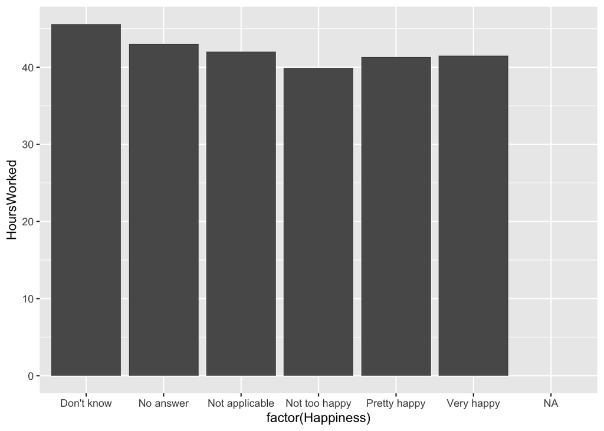

```r
ggplot(gss, aes(x = factor(Happiness), y = HoursWorked)) +
  stat_summary(fun = "mean", geom = "bar")
```

Above: Hours worked per week vs. Happiness

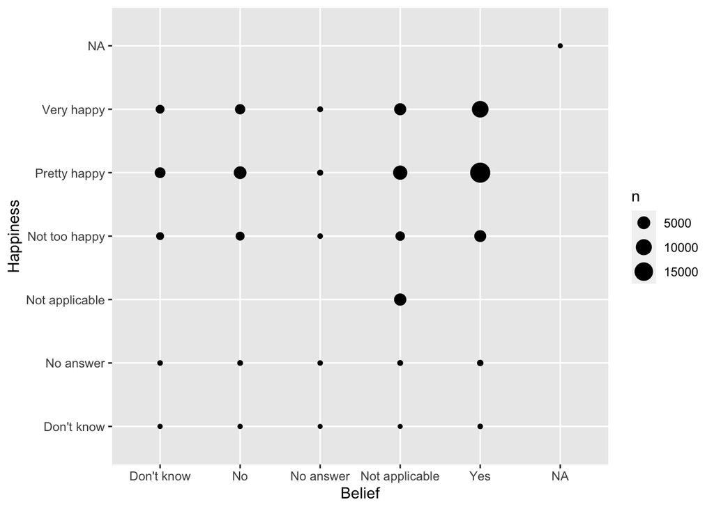

```r
ggplot(gss, aes(x = Belief, y = Happiness)) + geom_count()
```

Above: Belief after death vs. Happiess